# MTH 209 Data Manipulation and Management

Basic Data visualization using R

Angel Rivera-Martinez  
Department of Psychology  
University of Dayton

2024-10-17

# README

You can utilize the following single character keyboard shortcuts to enable alternate display modes:

- A: Switches show of current versus all slides (helpful for printing all pages)
- B: Make fonts large
- C: Show table of contents
- S: Make fonts smaller

# Brief Overview

In this session, we will use the Black Friday Data available in [Kaggle] (https://www.kaggle.com/datasets/pranavuikey/black-friday-sales-eda) to study how to make the following graphical displays.

Here is a list of common arguments:

- col: a vector of colors
- main: title for the plot
- xlim or ylim: limits for the x or y axis
- xlab or ylab: a label for the x axis
- font: fint used for the text, 1=plain; 2=bold; 3=italic, 4=bold italic
- font axis: font used for the axis
- cex.lab: font size for x and y labels

# Understand Your Data

In order to understand the customer purchase behavior against various products of different categories, the retail company “ABC Private Limited”, United Kingdom, shared purchase summary of various customers for selected high volume products from last month. The data contain the following variables.

- User_ID: User ID
- Product_ID: Product ID
- Gender: Sex of User
- Age: Age in bins
- Occupation: Occupation (Masked)
- City_Category: Category of the City (A,B,C)
- Stay_In_Current_City_Years: Number of years stay in current city
- Marital_Status: Marital Status
- Product_Category_1: Product Cateogry (Masked)
- Product_Category_2: Product may belong to other category also (Masked)
- Product_Category_3: Product may belong to other category also (Masked)
- Purchase: Purchase Amount

# Get a Glimpse of the Data

We can use the glimpse() function to get a glimpse of the data.

```r
glimpse(Friday)
```

```
## Rows: 550,068
## Columns: 12
## $ User_ID                    <int> 1000001, 1000001, 1000001, 1000001, 1000002…
## $ Product_ID                 <chr> "P00069042", "P00248942", "P00087842", "P00…
## $ Gender                     <chr> "F", "F", "F", "F", "M", "M", "M", "M", "M"…
## $ Age                        <chr> "0-17", "0-17", "0-17", "0-17", "55+", "26-…
## $ Occupation                 <int> 10, 10, 10, 10, 16, 15, 7, 7, 7, 20, 20, 20…
## $ City_Category              <chr> "A", "A", "A", "A", "C", "A", "B", "B", "B"…
## $ Stay_In_Current_City_Years <chr> "2", "2", "2", "2", "4+", "3", "2", "2", "2…
## $ Marital_Status             <int> 0, 0, 0, 0, 0, 0, 1, 1, 1, 1, 1, 1, 1, 1, 0…
## $ Product_Category_1         <int> 3, 1, 12, 12, 8, 1, 1, 1, 1, 8, 5, 8, 8, 1,…
## $ Product_Category_2         <int> NA, 6, NA, 14, NA, 2, 8, 15, 16, NA, 11, NA…
## $ Product_Category_3         <int> NA, 14, NA, NA, NA, NA, 17, NA, NA, NA, NA,…
## $ Purchase                   <int> 8370, 15200, 1422, 1057, 7969, 15227, 19215…
```

# Bar Chart - 1

Bar chart is a graphical display good for the general audience. Here, we study the distribution of Age Group of the company’s customers who purchased their products on Black Friday.

**Usage:** barplot (height, …)

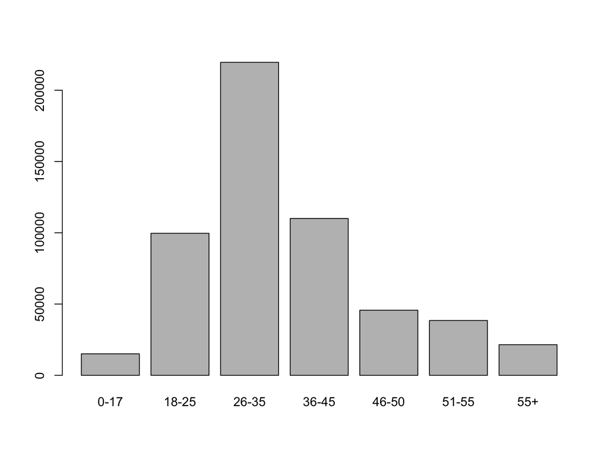

# Bar Chart - 2

We can have the horizontal bars. Using the argument col, we can assign a color for bars. The argument main could be used to change the title of the figure.

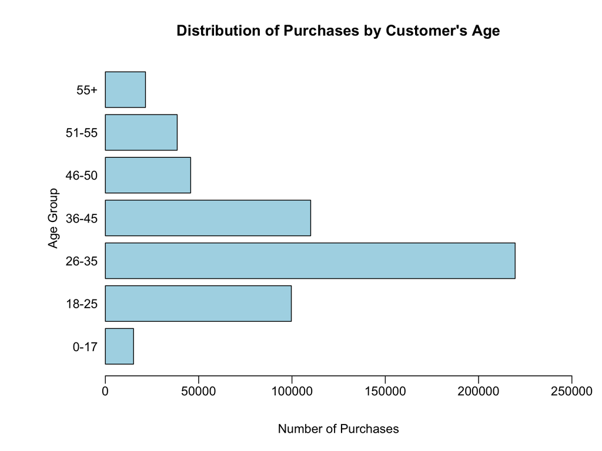

**Note:** The margin of a figure could be set using the par() function. The order of the setting is c(bottom, left, top, right)

# Bar Chart - 3

We can use RGB color code to assign colors.

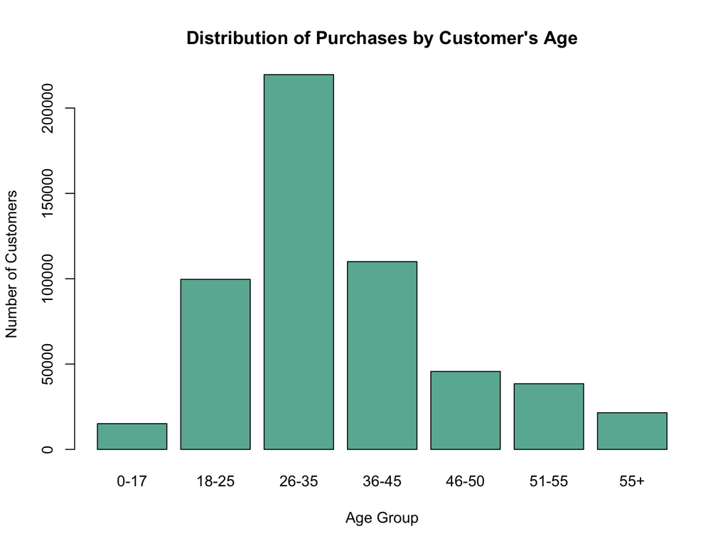

# Pie Chart - 1

Similarly, we can use pie chart to study the distribtion of the city category.

**Usage:** pie(height, …)

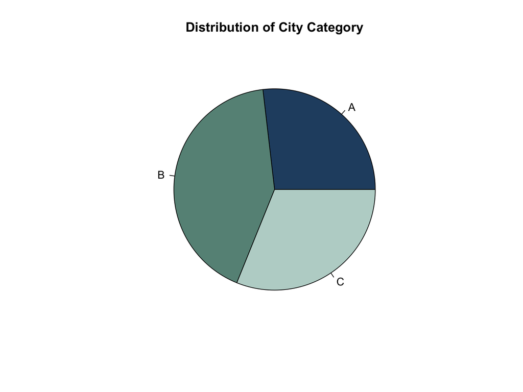

# Pie Chart - 2

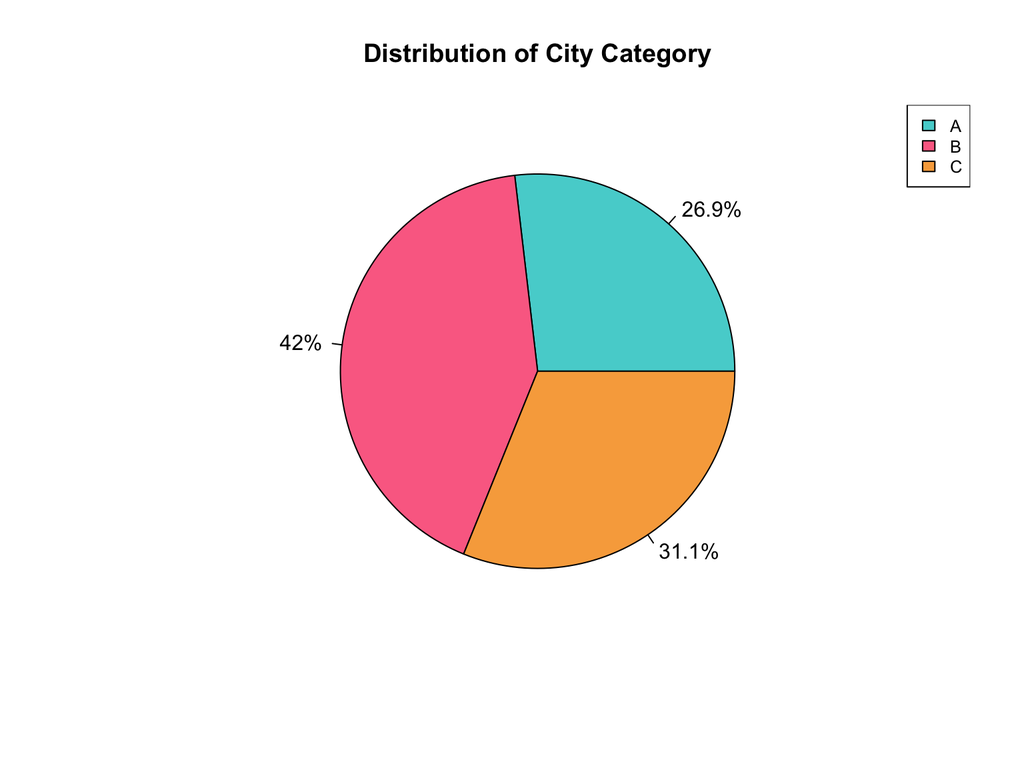

**Tip:** Use color paletter to choose colors (Google search: color sheme generator).

# Histogram

Histogram is used when we want to study the distribution of a quantitative variable. Here we study the distribution of customer purchase amount.

**Usage:** hist(x,…)

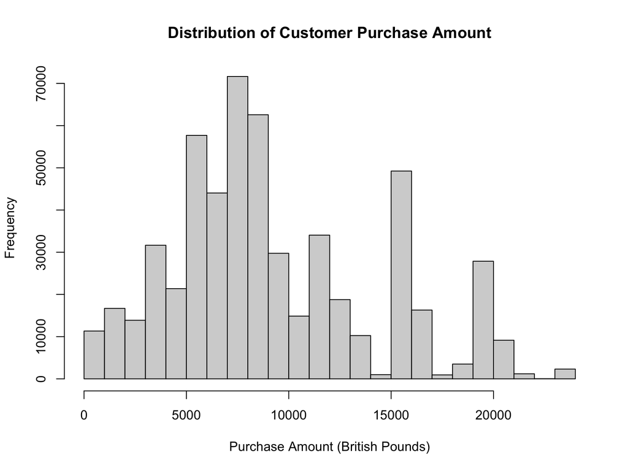

We can find that the distribution of histogram is multimodal.

# Boxplot - 1

Here, we talk about another graphical display that can be used to study the distribution of a quantitative variable: box and whisker plot (boxplot).

**Usage:** boxplot(x, …) or boxplot(formula, …)

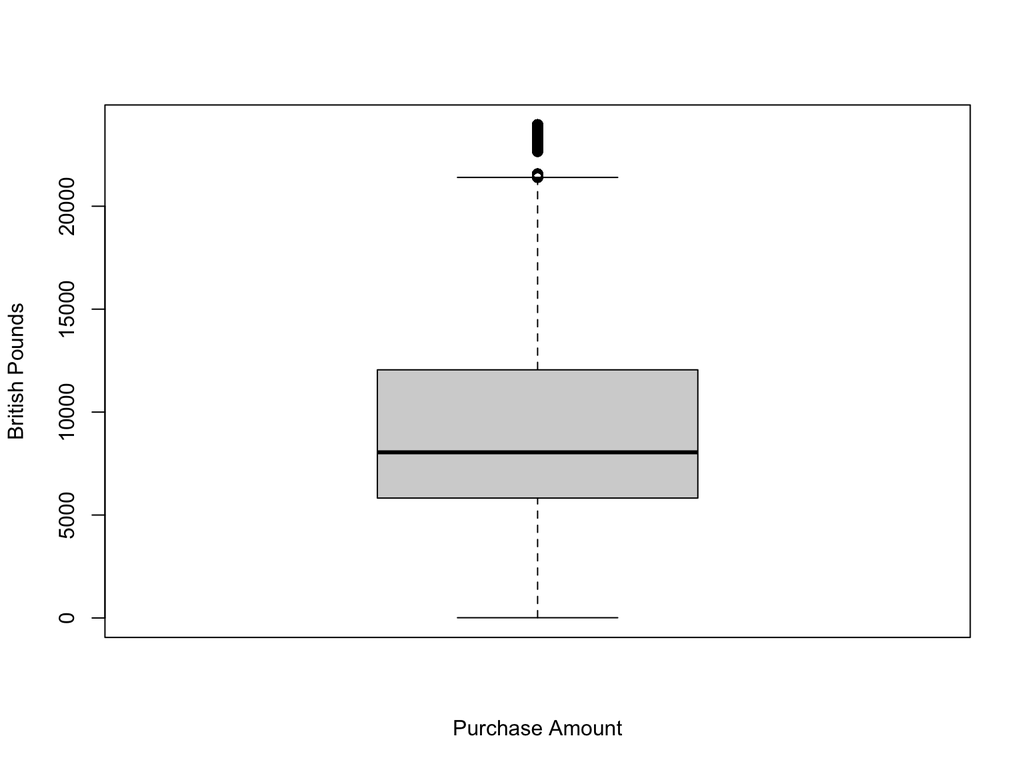

# Boxplot - 2

In general, a boxplot is used when we want to compare the distributions of several quantitative variables. In the following we study the distribution of customer purchase amount among different age groups.

In order to know how this can be done, we need to know how to define a formula in R.

**Usage:** A ~ B

- A: response variable
- B: explanatoru variables

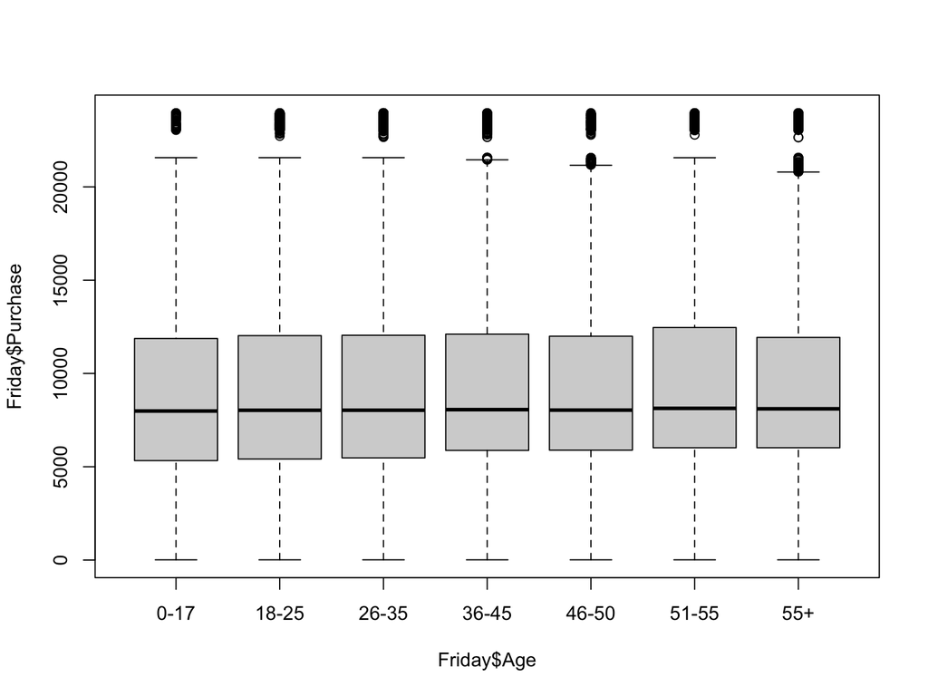

# Boxplot - 3

We can improve the quality of the boxplot by changing a few settings in the default settings.

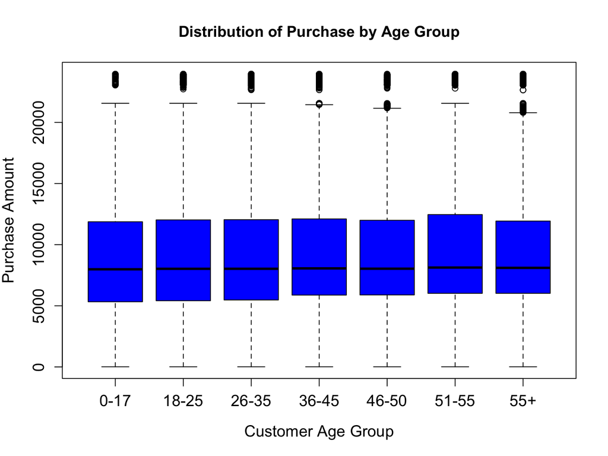

# Boxplot - 4

We can use the argument data to indicate that variables used are from a given data.

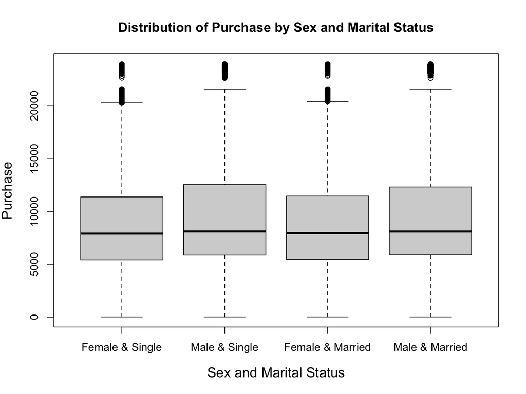

# Scatterplot - 1

When we want to study the relationship of two quantitative variables, a scatterplot can be used. Since this data set doesn’t have another quantitative variable, we will use the built-in data mtcars in R. Then we study the relationship of miles per gallon against the weight of vehicles.

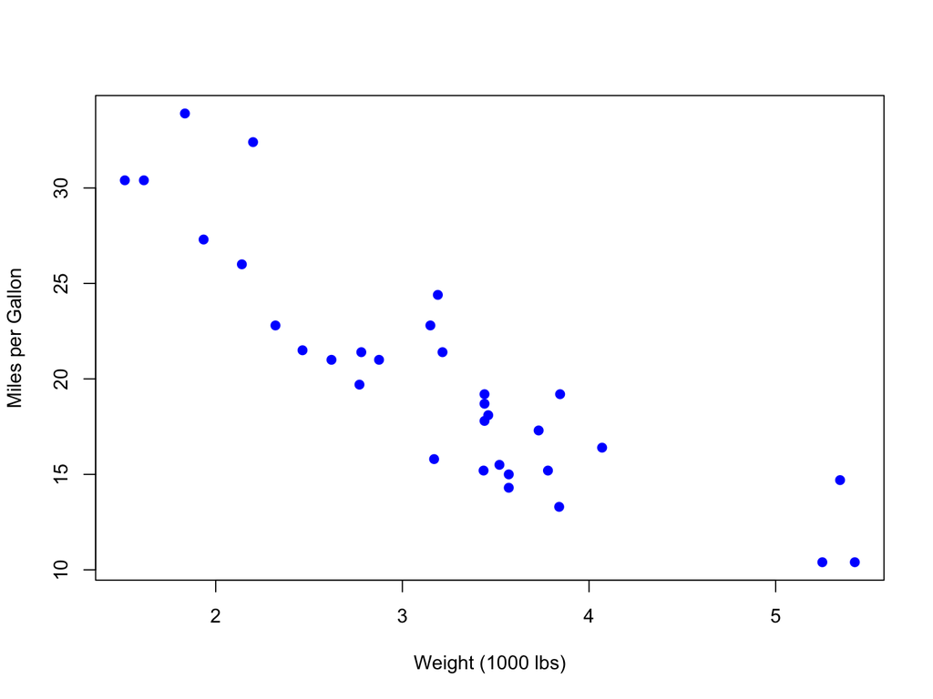

# Line Plot - 1

- type: “p” to draw only points; “1” to draw only lines; “o” to draw both points and lines.

# Line Plot- 2

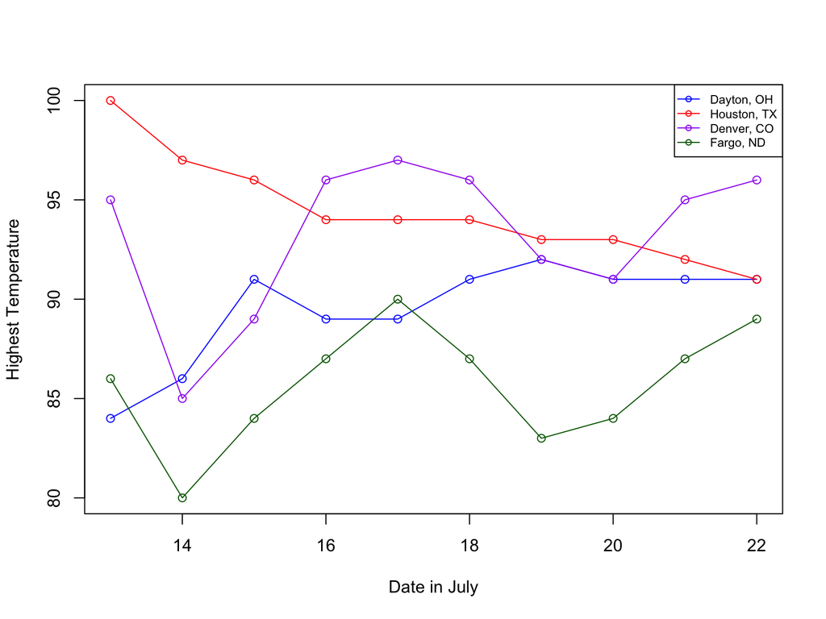